# Assignment 2: Monty Hall Simulation

Univeristy of Washington - Data Science Certification - Method for Data Analysis

Josh Jensen

July 12, 2016

### Problem

Monty Hall problem definition from Wikipedia:

*Suppose you’re on a game show, and you’re given the choice of three doors: Behind one door is a car; behind the others, goats. You pick a door, say No. 1, and the host, who knows what’s behind the doors, opens another door, say No. 3, which has a goat. He then says to you, “Do you want to pick door No. 2?” Is it to your advantage to switch your choice?*

### Create Monty Hall Simulation

First lets load the libraries we will use.

```r
library(dplyr)
library(ggplot2)
library(reshape2)
```

Now lets create a function that generates a data frame of `n` observations, with random initial door choices and random doors with the car behind. Using these randomized pieces of information, we’ll also determine if they would win following each of the strategies.

```r
simMontyHall <- function(n = 10000) {
  df <- data.frame(door_choice = trunc(runif(n, min = 1, max = 4)),   # generates a uniform random number of 1, 2, or 3
                   door_with_car = trunc(runif(n, min = 1, max = 4))  # generates a uniform random number of 1, 2, or 3
                   )
  # note: runif will not generate either of the extreme values unless max = min or max-min is small compared to min

  # create boolean columns for both switch & stay strategies
  df$stay_win <- ifelse(df$door_choice == df$door_with_car, T, F)

  # note: since Monty Hall will never reveal the car, a switching strategy will win as long as the car was not behind the original choice
  df$switch_win <- ifelse(df$door_choice != df$door_with_car, T, F)

  df
}
```

Using this function, lets run one million observations.

```r
df <- simMontyHall(1000000)
head(df)
```

```
##   door_choice door_with_car stay_win switch_win
## 1           2             1    FALSE       TRUE
## 2           2             1    FALSE       TRUE
## 3           1             3    FALSE       TRUE
## 4           1             3    FALSE       TRUE
## 5           1             2    FALSE       TRUE
## 6           3             2    FALSE       TRUE
```

### Summarize Results

Now lets calculate the probabilities & variances for each strategy. Note that because `stay_win` and `switch_win` are boolean columns, calculating the mean of the column is equivalent to calculating the probability of winning the car given the strategy.

```r
# create & print summary df
summary_df <- summarise(df, stay_prob = mean(stay_win),
                            stay_var = var(stay_win),
                            switch_prob = mean(switch_win),
                            switch_var = var(switch_win))
melt(summary_df)
```

```
##      variable     value
## 1   stay_prob 0.3339570
## 2    stay_var 0.2224299
## 3 switch_prob 0.6660430
## 4  switch_var 0.2224299
```

Now we can plot the differences between the simulated probabilities by the switch and stay strategies. Note that theoretically, stay should be $1/3$ and switch should be $2/3$.

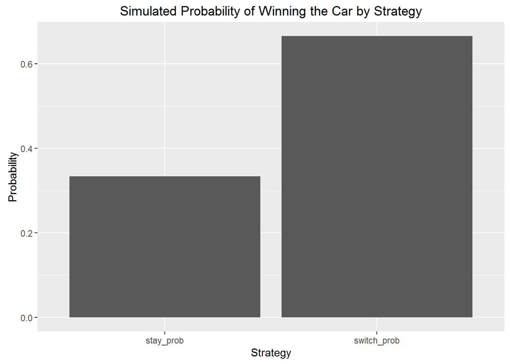

```r
prob_df <- melt(select(summary_df, ends_with("_prob")))

ggplot(prob_df, aes(x = variable, y = value)) +
  geom_bar(stat = "identity") +
  labs(title="Simulated Probability of Winning the Car by Strategy", x="Strategy", y="Probability")
```

We can also plot the variances of each of the strategies. Note that this is should be identical.

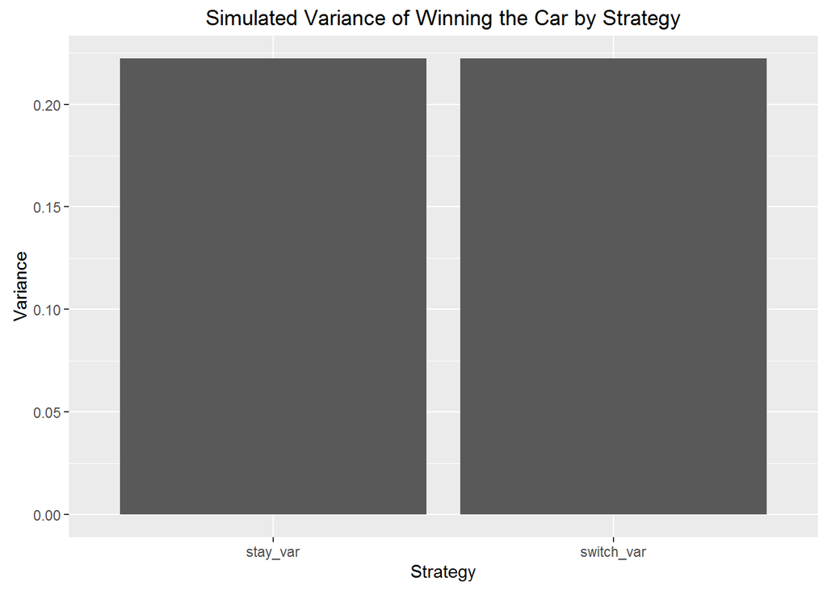

```r
var_df <- melt(select(summary_df, ends_with("_var")))

ggplot(var_df, aes(x = variable, y = value)) +
  geom_bar(stat = "identity") +
  labs(title="Simulated Variance of Winning the Car by Strategy", x="Strategy", y="Variance")
```